# Big Sales Mart

### Problem Statement

The data scientists at BigMart have collected 2013 sales data for 1559 products across 10 stores in different cities. Also, certain attributes of each product and store have been defined. The aim is to build a predictive model and find out the sales of each product at a particular store.

Using this model, BigMart will try to understand the properties of products and stores which play a key role in increasing sales.

### Data

We have train (8523) and test (5681) data set, train data set has both input and output variable(s). You need to predict the sales for test data set.

Item_Identifier - Unique product ID

Item_Weight - Weight of product

Item_Fat_Content - Whether the product is low fat or not

Item_Visibility - The % of total display area of all products in a store allocated to the particular product

Item_Type - The category to which the product belongs

Item_MRP - Maximum Retail Price (list price) of the product

Outlet_Identifier - Unique store ID

Outlet_Establishment_Year - The year in which store was established

Outlet_Size - The size of the store in terms of ground area covered

Outlet_Location_Type - The type of city in which the store is located

Outlet_Type - Whether the outlet is just a grocery store or some sort of supermarket

Item_Outlet_Sales - Sales of the product in the particulat store. This is the outcome variable to be predicted.

```python
# Importing the Libraries
import pandas as pd
import numpy as np
import matplotlib.pyplot as plt
import seaborn as sns
```

```python
train = pd.read_csv("C://Users//Classroom//Downloads//Train_UWu5bXk.csv")
test = pd.read_csv("C://Users//Classroom//Downloads//Test_u94Q5KV.csv")
```

```python
train.head()
```

|  | Item_Identifier | Item_Weight | Item_Fat_Content | Item_Visibility | Item_Type | Item_MRP | Outlet_Identifier | Outlet_Establishment_Year | Outlet_Size | Outlet_Location_Type | Outlet_Type | Item_Outlet_Sales |
| --- | --- | --- | --- | --- | --- | --- | --- | --- | --- | --- | --- | --- |
| 0 | FDA15 | 9.30 | Low Fat | 0.016047 | Dairy | 249.8092 | OUT049 | 1999 | Medium | Tier 1 | Supermarket Type1 | 3735.1380 |
| 1 | DRC01 | 5.92 | Regular | 0.019278 | Soft Drinks | 48.2692 | OUT018 | 2009 | Medium | Tier 3 | Supermarket Type2 | 443.4228 |
| 2 | FDN15 | 17.50 | Low Fat | 0.016760 | Meat | 141.6180 | OUT049 | 1999 | Medium | Tier 1 | Supermarket Type1 | 2097.2700 |
| 3 | FDX07 | 19.20 | Regular | 0.000000 | Fruits and Vegetables | 182.0950 | OUT010 | 1998 | NaN | Tier 3 | Grocery Store | 732.3800 |
| 4 | NCD19 | 8.93 | Low Fat | 0.000000 | Household | 53.8614 | OUT013 | 1987 | High | Tier 3 | Supermarket Type1 | 994.7052 |

## Univariate Analysis

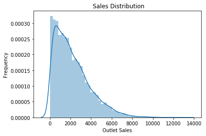

```python
# Target Variable
g = sns.distplot(train.Item_Outlet_Sales) # Sales is positively skewed
g.set(xlabel = "Outlet Sales", ylabel = "Frequency", title = " Sales Distribution")
plt.tight_layout()
```

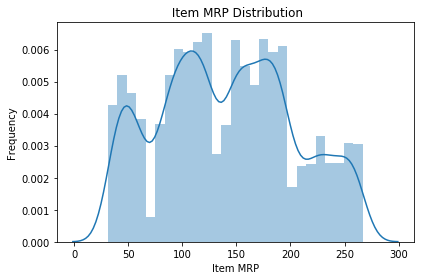

```python
#Item_MRP
g = sns.distplot(train.Item_MRP) # Sales is positively skewed
g.set(xlabel = "Item MRP", ylabel = "Frequency", title = " Item MRP Distribution")
plt.tight_layout()
```

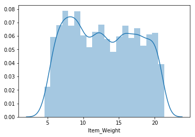

```python
# Item_Weight
sns.distplot(train[train.Item_Weight.notnull()].Item_Weight)
```

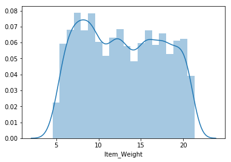

```python
sns.distplot(train.Item_Weight.dropna())
```

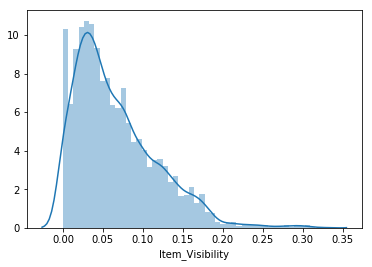

```python
# Item Visibility Plot
sns.distplot(train.Item_Visibility)
```

## Univariate - Categorical Columns

```python
train.columns
```

```
Index(['Item_Identifier', 'Item_Weight', 'Item_Fat_Content', 'Item_Visibility',
       'Item_Type', 'Item_MRP', 'Outlet_Identifier',
       'Outlet_Establishment_Year', 'Outlet_Size', 'Outlet_Location_Type',
       'Outlet_Type', 'Item_Outlet_Sales'],
      dtype='object')
```

[figure not shown]

```python
sns.countplot(x = 'Item_Fat_Content', data=test) # Low fat content is sold more
```

```python
# Saw that low fat, lf and Low Fat represents the same and same for Regular and reg.
#train.Item_Fat_Content = train.Item_Fat_Content.replace(to_replace="reg", value="Regular")
train.Item_Fat_Content = train.Item_Fat_Content.replace(to_replace=["low fat", "LF", "reg"],
                                                       value = ["Low Fat", "Low Fat", "Regular"])
```

```python
test.Item_Fat_Content = test.Item_Fat_Content.replace(to_replace=["low fat", "LF", "reg"],
                                                       value = ["Low Fat", "Low Fat", "Regular"])
```

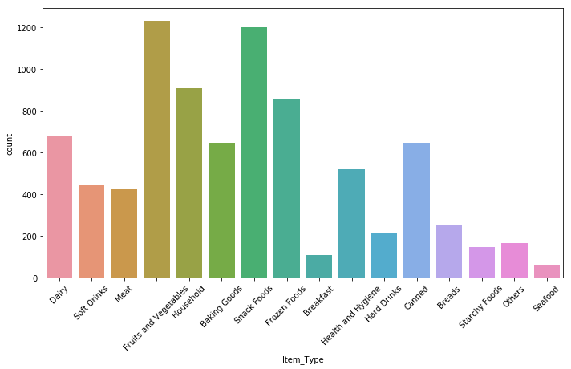

```python
# Item Type
plt.figure(figsize=[10,6.5])
sns.countplot(train.Item_Type)
plt.xticks(rotation = 45)
plt.tight_layout()
```

```python
train.Item_Type.value_counts()
```

```
Fruits and Vegetables    1232
Snack Foods              1200
Household                 910
Frozen Foods              856
Dairy                     682
Canned                    649
Baking Goods              648
Health and Hygiene        520
Soft Drinks               445
Meat                      425
Breads                    251
Hard Drinks               214
Others                    169
Starchy Foods             148
Breakfast                 110
Seafood                    64
Name: Item_Type, dtype: int64
```

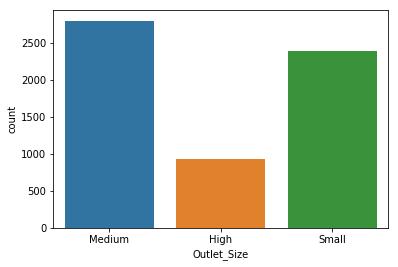

```python
# Outlet Size
sns.countplot(x = 'Outlet_Size', data = train) # Medium is the most visible outlet
```

### Bivariate Analysis

#### Categorical Vs Numerical

1. Outlet Size Vs Outlet Sales
2. Item Type Vs Sales

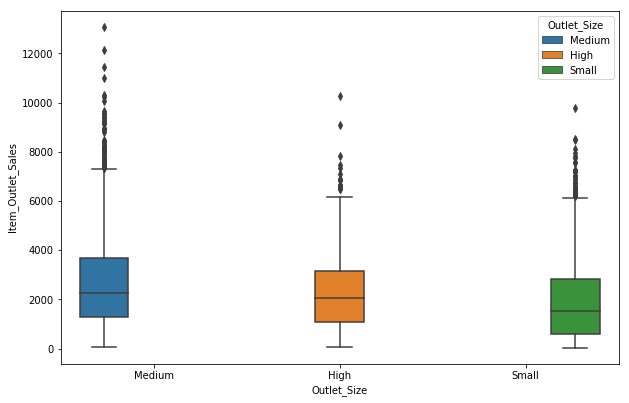

```python
plt.figure(figsize=[10,6.5])
sns.boxplot(x = 'Outlet_Size', y = "Item_Outlet_Sales", data = train, hue = 'Outlet_Size')
```

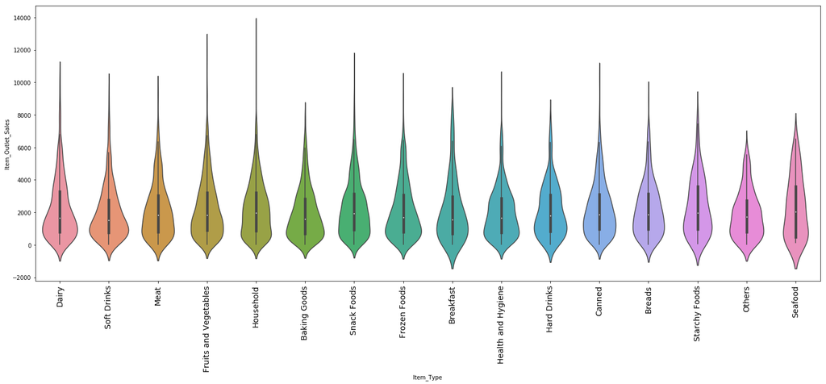

```python
plt.figure(figsize=[25,9])
a = sns.violinplot(x = 'Item_Type', y = "Item_Outlet_Sales", data = train)
plt.xticks(rotation = 90, fontsize = 14)
```

```python
# Statistical Summary of Item Type Vs Sales
train.groupby("Item_Type").Item_Outlet_Sales.describe()
```

| Item_Type | count | mean | std | min | 25% | 50% | 75% | max |
| --- | --- | --- | --- | --- | --- | --- | --- | --- |
| Baking Goods | 648.0 | 1952.971207 | 1546.788045 | 37.2848 | 705.08220 | 1577.9460 | 2823.82425 | 7931.6754 |
| Breads | 251.0 | 2204.132226 | 1644.235914 | 35.2874 | 968.73900 | 1860.2452 | 3145.90500 | 8958.3390 |
| Breakfast | 110.0 | 2111.808651 | 1911.693586 | 39.9480 | 679.11600 | 1554.6430 | 2970.30025 | 8209.3140 |
| Canned | 649.0 | 2225.194904 | 1645.235638 | 37.9506 | 952.09400 | 1860.2452 | 3101.29640 | 10306.5840 |
| Dairy | 682.0 | 2232.542597 | 1884.404698 | 40.6138 | 788.97300 | 1650.8511 | 3296.20935 | 10256.6490 |
| Frozen Foods | 856.0 | 2132.867744 | 1724.777720 | 36.6190 | 808.94700 | 1687.1372 | 3079.49145 | 9678.0688 |
| Fruits and Vegetables | 1232.0 | 2289.009592 | 1799.503459 | 45.2744 | 884.84820 | 1830.9500 | 3227.13260 | 12117.5600 |
| Hard Drinks | 214.0 | 2139.221622 | 1606.191587 | 37.9506 | 834.91320 | 1816.6353 | 3071.33540 | 7843.1240 |
| Health and Hygiene | 520.0 | 2010.000265 | 1553.633063 | 34.6216 | 758.84555 | 1669.4935 | 2884.57850 | 9779.9362 |
| Household | 910.0 | 2258.784300 | 1692.245757 | 33.2900 | 853.38915 | 1981.4208 | 3236.78670 | 13086.9648 |
| Meat | 425.0 | 2158.977911 | 1695.231081 | 47.9376 | 782.98080 | 1829.6184 | 3036.04800 | 9390.4432 |
| Others | 169.0 | 1926.139702 | 1431.860471 | 39.9480 | 790.97040 | 1713.7692 | 2719.79300 | 6008.8450 |
| Seafood | 64.0 | 2326.065928 | 1842.988719 | 149.8050 | 473.38380 | 2055.3246 | 3589.32780 | 6503.5344 |
| Snack Foods | 1200.0 | 2277.321739 | 1705.121755 | 33.9558 | 918.80400 | 1944.1360 | 3143.57470 | 10993.6896 |
| Soft Drinks | 445.0 | 2006.511735 | 1674.249752 | 33.2900 | 771.66220 | 1518.0240 | 2759.07520 | 9554.2300 |
| Starchy Foods | 148.0 | 2374.332773 | 1773.945328 | 58.5904 | 958.75200 | 1968.1048 | 3592.65680 | 8132.0812 |

### Bivariate

Numerical Columns

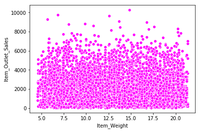

```python
# Item Weight Vs Sales - No Pattern
sns.scatterplot(x = "Item_Weight", y = "Item_Outlet_Sales", data = train, color = "magenta")
```

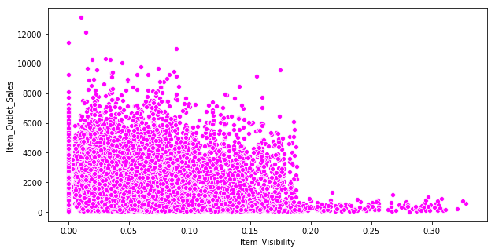

```python
# Item Visibility vs Sales
plt.figure(figsize=[10,5])
sns.scatterplot(x = "Item_Visibility", y = "Item_Outlet_Sales", data = train, color = "magenta")
```

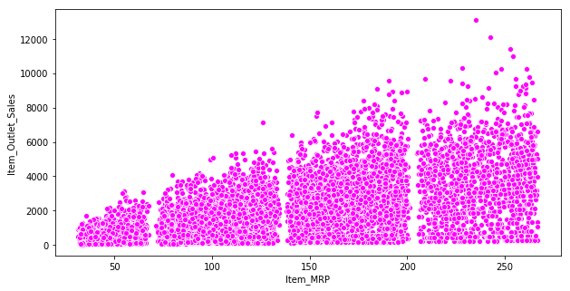

```python
# Item Visibility vs Sales
plt.figure(figsize=[10,5])
sns.scatterplot(x = "Item_MRP", y = "Item_Outlet_Sales", data = train, color = "magenta")
```

## Missing Values

```python
train.isnull().sum()
```

[output not shown]

```python
test.isnull().sum()
```

```
Item_Identifier                 0
Item_Weight                   976
Item_Fat_Content                0
Item_Visibility                 0
Item_Type                       0
Item_MRP                        0
Outlet_Identifier               0
Outlet_Establishment_Year       0
Outlet_Size                  1606
Outlet_Location_Type            0
Outlet_Type                     0
dtype: int64
```

```python
# Item Weight Imputation
```

```python
train[train.Item_Weight.isnull()]
```

[output not shown]

```python
train[train.Item_Identifier=="FDN52"].Item_Weight
```

```
927   NaN
Name: Item_Weight, dtype: float64
```

```python
train["Item_Weight"]=train.groupby("Item_Identifier").transform(lambda x: x.fillna(x.notnull().mean()))
```

```python
test["Item_Weight"]=test.groupby("Item_Identifier").transform(lambda x: x.fillna(x.notnull().mean()))
```

```python
# Outlet Size
train.Outlet_Size.value_counts()
```

```
Medium    2793
Small     2388
High       932
Name: Outlet_Size, dtype: int64
```

```python
# removing na values
train.Outlet_Size=train.Outlet_Size.fillna(value="Medium")
```

```python
train.isnull().sum()
```

```
Item_Identifier              0
Item_Weight                  0
Item_Fat_Content             0
Item_Visibility              0
Item_Type                    0
Item_MRP                     0
Outlet_Identifier            0
Outlet_Establishment_Year    0
Outlet_Size                  0
Outlet_Location_Type         0
Outlet_Type                  0
Item_Outlet_Sales            0
dtype: int64
```

# Feature Engg

```python
train.head()
```

[output not shown]

```python
# Price per Unit
train["Price_PerUnit"] = train.Item_Outlet_Sales/train.Item_MRP
```

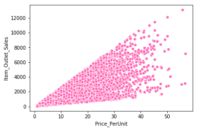

```python
sns.scatterplot(x = "Price_PerUnit", y = "Item_Outlet_Sales", data = train, color="hotpink")
```

```python
train.Item_Identifier[1][0:2]
```

```
'DR'
```

```python
# Extracting Column ID
count = 0
itemid = []
for i in np.arange(0, len(train.Item_Identifier)):
    itemid.append(train.Item_Identifier[i][0:2])
```

```python
#Assigning the Column ID to the Dataset
train["Item_ID"]=pd.Series(itemid)
```

# Dummies

```python
train.head()
```

|  | Item_Identifier | Item_Weight | Item_Fat_Content | Item_Visibility | Item_Type | Item_MRP | Outlet_Identifier | Outlet_Establishment_Year | Outlet_Size | Outlet_Location_Type | Outlet_Type | Item_Outlet_Sales | Price_PerUnit | Item_ID |
| --- | --- | --- | --- | --- | --- | --- | --- | --- | --- | --- | --- | --- | --- | --- |
| 0 | FDA15 | 9.3 | Low Fat | 0.016047 | Dairy | 249.8092 | OUT049 | 1999 | Medium | Tier 1 | Supermarket Type1 | 3735.1380 | 14.951963 | FD |
| 1 | DRC01 | 5.92 | Regular | 0.019278 | Soft Drinks | 48.2692 | OUT018 | 2009 | Medium | Tier 3 | Supermarket Type2 | 443.4228 | 9.186454 | DR |
| 2 | FDN15 | 17.5 | Low Fat | 0.016760 | Meat | 141.6180 | OUT049 | 1999 | Medium | Tier 1 | Supermarket Type1 | 2097.2700 | 14.809346 | FD |
| 3 | FDX07 | 19.2 | Regular | 0.000000 | Fruits and Vegetables | 182.0950 | OUT010 | 1998 | Medium | Tier 3 | Grocery Store | 732.3800 | 4.021967 | FD |
| 4 | NCD19 | 8.93 | Low Fat | 0.000000 | Household | 53.8614 | OUT013 | 1987 | High | Tier 3 | Supermarket Type1 | 994.7052 | 18.467868 | NC |

### Test Set

```python
test.isnull().sum()
```

```
Item_Identifier                 0
Item_Weight                     0
Item_Fat_Content                0
Item_Visibility                 0
Item_Type                       0
Item_MRP                        0
Outlet_Identifier               0
Outlet_Establishment_Year       0
Outlet_Size                  1606
Outlet_Location_Type            0
Outlet_Type                     0
dtype: int64
```

```python
test.Outlet_Size.value_counts()
```

```
Medium    1862
Small     1592
High       621
Name: Outlet_Size, dtype: int64
```

```python
# removing na values
test.Outlet_Size=test.Outlet_Size.fillna(value="Medium")
```

```python
# Extracting Column ID
count = 0
itemid = []
for i in np.arange(0, len(test.Item_Identifier)):
    itemid.append(test.Item_Identifier[i][0:2])
```

```python
#Assigning the Column ID to the Dataset
test["Item_ID"]=pd.Series(itemid)
```

```python
# Dropping id from train and test
train = train.drop("Item_Identifier", axis = 1)
test = test.drop("Item_Identifier", axis = 1)
```

```python
# Dropping Outlet Year from train and test
train = train.drop("Outlet_Establishment_Year", axis = 1)
test = test.drop("Outlet_Establishment_Year", axis = 1)
```

```python
train.shape
```

```
(8523, 12)
```

```python
train.head()
```

|  | Item_Weight | Item_Fat_Content | Item_Visibility | Item_Type | Item_MRP | Outlet_Identifier | Outlet_Size | Outlet_Location_Type | Outlet_Type | Item_Outlet_Sales | Price_PerUnit | Item_ID |
| --- | --- | --- | --- | --- | --- | --- | --- | --- | --- | --- | --- | --- |
| 0 | 9.3 | Low Fat | 0.016047 | Dairy | 249.8092 | OUT049 | Medium | Tier 1 | Supermarket Type1 | 3735.1380 | 14.951963 | FD |
| 1 | 5.92 | Regular | 0.019278 | Soft Drinks | 48.2692 | OUT018 | Medium | Tier 3 | Supermarket Type2 | 443.4228 | 9.186454 | DR |
| 2 | 17.5 | Low Fat | 0.016760 | Meat | 141.6180 | OUT049 | Medium | Tier 1 | Supermarket Type1 | 2097.2700 | 14.809346 | FD |
| 3 | 19.2 | Regular | 0.000000 | Fruits and Vegetables | 182.0950 | OUT010 | Medium | Tier 3 | Grocery Store | 732.3800 | 4.021967 | FD |
| 4 | 8.93 | Low Fat | 0.000000 | Household | 53.8614 | OUT013 | High | Tier 3 | Supermarket Type1 | 994.7052 | 18.467868 | NC |

```python
train.info()
```

```
<class 'pandas.core.frame.DataFrame'>
RangeIndex: 8523 entries, 0 to 8522
Data columns (total 12 columns):
Item_Weight             8523 non-null float64
Item_Fat_Content        8523 non-null object
Item_Visibility         8523 non-null float64
Item_Type               8523 non-null object
Item_MRP                8523 non-null float64
Outlet_Identifier       8523 non-null object
Outlet_Size             8523 non-null object
Outlet_Location_Type    8523 non-null object
Outlet_Type             8523 non-null object
Item_Outlet_Sales       8523 non-null float64
Price_PerUnit           8523 non-null float64
Item_ID                 8523 non-null object
dtypes: float64(5), object(7)
memory usage: 799.1+ KB
```

```python
train.Item_Weight = train.Item_Weight.astype("float64")
```

```python
newtrain = pd.get_dummies(train)
```

```python
test.info()
```

```
<class 'pandas.core.frame.DataFrame'>
RangeIndex: 5681 entries, 0 to 5680
Data columns (total 10 columns):
Item_Weight             5681 non-null object
Item_Fat_Content        5681 non-null object
Item_Visibility         5681 non-null float64
Item_Type               5681 non-null object
Item_MRP                5681 non-null float64
Outlet_Identifier       5681 non-null object
Outlet_Size             5681 non-null object
Outlet_Location_Type    5681 non-null object
Outlet_Type             5681 non-null object
Item_ID                 5681 non-null object
dtypes: float64(2), object(8)
memory usage: 443.9+ KB
```

```python
test.Item_Weight = test.Item_Weight.astype("float64")
```

```python
newtest = pd.get_dummies(test)
```

```python
newtrain.shape
```

```
(8523, 46)
```

```python
newtest.shape
```

```
(5681, 44)
```

```python
newtrain.head()
```

|  | Item_Weight | Item_Visibility | Item_MRP | Item_Outlet_Sales | Price_PerUnit | Item_Fat_Content_Low Fat | Item_Fat_Content_Regular | Item_Type_Baking Goods | Item_Type_Breads | Item_Type_Breakfast | ... | Outlet_Location_Type_Tier 1 | Outlet_Location_Type_Tier 2 | Outlet_Location_Type_Tier 3 | Outlet_Type_Grocery Store | Outlet_Type_Supermarket Type1 | Outlet_Type_Supermarket Type2 | Outlet_Type_Supermarket Type3 | Item_ID_DR | Item_ID_FD | Item_ID_NC |
| --- | --- | --- | --- | --- | --- | --- | --- | --- | --- | --- | --- | --- | --- | --- | --- | --- | --- | --- | --- | --- | --- |
| 0 | 9.30 | 0.016047 | 249.8092 | 3735.1380 | 14.951963 | 1 | 0 | 0 | 0 | 0 | ... | 1 | 0 | 0 | 0 | 1 | 0 | 0 | 0 | 1 | 0 |
| 1 | 5.92 | 0.019278 | 48.2692 | 443.4228 | 9.186454 | 0 | 1 | 0 | 0 | 0 | ... | 0 | 0 | 1 | 0 | 0 | 1 | 0 | 1 | 0 | 0 |
| 2 | 17.50 | 0.016760 | 141.6180 | 2097.2700 | 14.809346 | 1 | 0 | 0 | 0 | 0 | ... | 1 | 0 | 0 | 0 | 1 | 0 | 0 | 0 | 1 | 0 |
| 3 | 19.20 | 0.000000 | 182.0950 | 732.3800 | 4.021967 | 0 | 1 | 0 | 0 | 0 | ... | 0 | 0 | 1 | 1 | 0 | 0 | 0 | 0 | 1 | 0 |
| 4 | 8.93 | 0.000000 | 53.8614 | 994.7052 | 18.467868 | 1 | 0 | 0 | 0 | 0 | ... | 0 | 0 | 1 | 0 | 1 | 0 | 0 | 0 | 0 | 1 |

5 rows × 46 columns

```python
# Standard Scaling
from sklearn.preprocessing import StandardScaler
```

```python
sc = StandardScaler()
```

```python
new_train = sc.fit_transform(newtrain)
```

```python
new_train = pd.DataFrame(new_train)
```

```python
new_train.columns=newtrain.columns
```

```python
new_train.head()
```

|  | Item_Weight | Item_Visibility | Item_MRP | Item_Outlet_Sales | Price_PerUnit | Item_Fat_Content_Low Fat | Item_Fat_Content_Regular | Item_Type_Baking Goods | Item_Type_Breads | Item_Type_Breakfast | ... | Outlet_Location_Type_Tier 1 | Outlet_Location_Type_Tier 2 | Outlet_Location_Type_Tier 3 | Outlet_Type_Grocery Store | Outlet_Type_Supermarket Type1 | Outlet_Type_Supermarket Type2 | Outlet_Type_Supermarket Type3 | Item_ID_DR | Item_ID_FD | Item_ID_NC |
| --- | --- | --- | --- | --- | --- | --- | --- | --- | --- | --- | --- | --- | --- | --- | --- | --- | --- | --- | --- | --- | --- |
| 0 | -0.237664 | -0.970732 | 1.747454 | 0.910601 | -0.051536 | 0.738147 | -0.738147 | -0.286855 | -0.174193 | -0.114346 | ... | 1.602840 | -0.696678 | -0.804732 | -0.381529 | 0.726802 | -0.349551 | -0.351028 | -0.321627 | 0.625708 | -0.480558 |
| 1 | -0.780886 | -0.908111 | -1.489023 | -1.018440 | -0.678759 | -1.354743 | 1.354743 | -0.286855 | -0.174193 | -0.114346 | ... | -0.623893 | -0.696678 | 1.242650 | -0.381529 | -1.375891 | 2.860816 | -0.351028 | 3.109193 | -1.598190 | -0.480558 |
| 2 | 1.080211 | -0.956917 | 0.010040 | -0.049238 | -0.067051 | 0.738147 | -0.738147 | -0.286855 | -0.174193 | -0.114346 | ... | 1.602840 | -0.696678 | -0.804732 | -0.381529 | 0.726802 | -0.349551 | -0.351028 | -0.321627 | 0.625708 | -0.480558 |
| 3 | 1.353429 | -1.281758 | 0.660050 | -0.849103 | -1.240598 | -1.354743 | 1.354743 | -0.286855 | -0.174193 | -0.114346 | ... | -0.623893 | -0.696678 | 1.242650 | 2.621031 | -1.375891 | -0.349551 | -0.351028 | -0.321627 | 0.625708 | -0.480558 |
| 4 | -0.297129 | -1.281758 | -1.399220 | -0.695373 | 0.330956 | 0.738147 | -0.738147 | -0.286855 | -0.174193 | -0.114346 | ... | -0.623893 | -0.696678 | 1.242650 | -0.381529 | 0.726802 | -0.349551 | -0.351028 | -0.321627 | -1.598190 | 2.080915 |

5 rows × 46 columns

```python
new_test = sc.fit_transform(newtest)
```

```python
new_test = pd.DataFrame(new_test)
new_test.columns=newtest.columns
```

```python
new_train.shape
```

```
(8523, 46)
```

```python
new_test.shape
```

```
(5681, 44)
```

```python
from sklearn.cross_validation import train_test_split
```

```python
new_train = new_train.drop("Price_PerUnit", axis = 1)
```

```python
x = new_train.drop("Item_Outlet_Sales", axis = 1)
```

```python
y = new_train.Item_Outlet_Sales
```

```python
# Decision Tree
from sklearn.tree import DecisionTreeRegressor
dtree = DecisionTreeRegressor()
```

```python
# Tune our training data
model_tree = dtree.fit(x, y)
```

```python
# Making the prediction
pred_tree = dtree.predict(new_test)
```

```python
# scaling it back again
scaleddata = sc.fit_transform(pd.DataFrame(train.Item_Outlet_Sales))
```

```python
# Applying Inverse
modeledvalues = sc.inverse_transform(pred_tree)
```

```python
pred_tree
```

```
array([-0.28568557, -0.06679556, -0.84988334, ..., -0.39571584,
        2.96879135, -0.32938554])
```

```python
# Solution Data Frame
solution = pd.DataFrame({
                         "Outlet_Identifier": test.Outlet_Identifier,
                        "Item_Outlet_Sales":modeledvalues})
```

```python
solution.head()
```

|  | Outlet_Identifier | Item_Outlet_Sales |
| --- | --- | --- |
| 0 | OUT049 | 1693.7952 |
| 1 | OUT017 | 2067.3090 |
| 2 | OUT010 | 731.0484 |
| 3 | OUT017 | 4287.7520 |
| 4 | OUT027 | 7170.6660 |

```python
#Export it back into the system
solution.to_csv("Decision Tree Model.csv") # RMSE 1600
```

```python
cd
```

```
C:\Users\Classroom
```

```python
# Decision Tree
from sklearn.ensemble import RandomForestRegressor
rf =RandomForestRegressor()
```

```python
# Tune our training data
model_rf = rf.fit(x, y)

# Making the prediction
pred_rf = rf.predict(new_test)

# Applying Inverse
modeledvalues = sc.inverse_transform(pred_rf)
```

```python
# Solution Data Frame
solution = pd.DataFrame({
                         "Outlet_Identifier": test.Outlet_Identifier,
                        "Item_Outlet_Sales":modeledvalues})
```

```python
#Export it back into the system
solution.to_csv("RF Model.csv") # rmse 1264
```